# Functional trend estimation with ftrend

## Model and estimator

The package implements the estimator of Martínez-Hernández and Genton (2021) for the model

$$Y_n(s) = T(s, n/N) + X_n(s), \qquad s
\in D,\; n = 1, \dots, N,$$

where $T: D \times [0,1] \to \mathbb{R}$ is a deterministic trend surface and $\{X_n\}$ is a zero-mean stationary functional time series. The trend is represented as a tensor product of B-splines, $T(s, t) = \nu(s)^\top \Theta\, \eta(t)$, and $\Theta$ minimises

$$\sum_{n=1}^N \int_D \{Y_n(s) -
\nu(s)^\top \Theta\, \eta(n/N)\}^2\,ds
+ \lambda_1 \int_0^1\!\!\int_D \Big(\frac{\partial^2 T}{\partial
s^2}\Big)^2 ds\,dt
+ \lambda_2 \int_D\!\int_0^1 \Big(\frac{\partial^2 T}{\partial
t^2}\Big)^2 dt\,ds .$$

Internally, $D$ and the time axis are rescaled to $[0, 1]$ and the integral over $D$ is approximated by trapezoidal quadrature on each curve. The smoothing parameters are selected by REML on marginal means: $\lambda_1$ from the mean curve $N^{-1}\sum_n Y_n(s)$ and $\lambda_2$ from the series $\int_D Y_n(s)\,ds$ (Section 3.3 of the paper). These marginal rules are available as `select = "reml-bspline"` and `select = "reml-supplement"`. By default, however, the smoothing parameters are chosen by leave-block-out cross-validation over the whole surface (`select = "cv"`): each curve is predicted from a fit that leaves out the curves within $l$ time steps of it, which removes the bias caused by the serial dependence of $X_n$. Only the selection changes; the estimator is the one of the paper (see `?ftrend`).

## A simulated example

`simulate_fts()` generates data as in Section 4 of the paper. Here the trend is $T_2(s, t) = 25\,t \sin(2\pi s)$ and $X_n$ is a FAR(1) process with Brownian-motion innovations.

```r
sim <- simulate_fts(N = 200, m = 50, trend = "T2", norm = 0.5, seed = 1)
fit <- ftrend(sim$Y, s = sim$s)
fit
```

```
#> Functional trend estimate (penalised tensor-product B-splines)
#> Call: ftrend(Y = sim$Y, s = sim$s)
#> N = 200 curves; domain [0, 1]; common grid
#> Bases: k1 = 10, k2 = 15 (order 4, 4)
#> lambda1 = 4.416e-06 [CV (leave-block-out)], lambda2 = 475.2 [CV (leave-block-out)]
#> Effective degrees of freedom: 19.86
```

Figure 1 shows the estimated surface, and Figure 2 the trend curves $\hat T(\cdot, n/N)$ coloured from early (dark) to late (light) times.

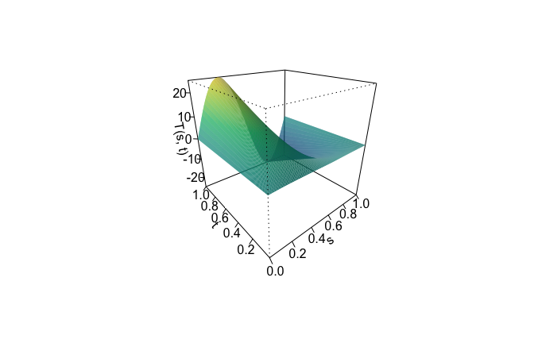

Figure 1. Estimated trend surface for the simulated data.

```r
plot(fit, type = "surface")
```

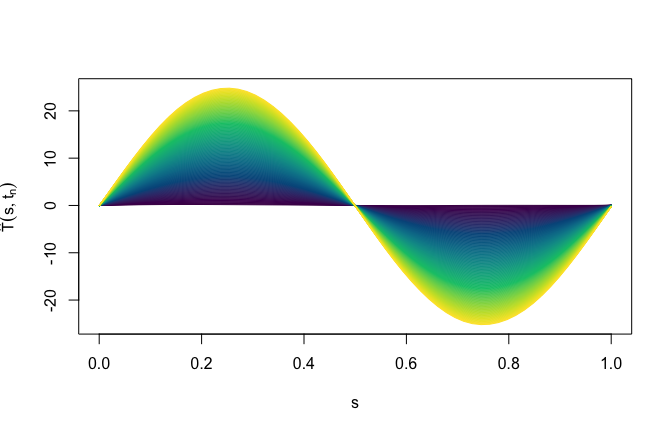

Figure 2. Estimated trend curves for the simulated data.

```r
plot(fit, type = "curves")
```

The integrated squared error against the true trend is

```r
ise(sim$trend, predict(fit, s = sim$s), sim$s, sim$t)
```

```
#> [1] 0.008473833
```

`residuals()` returns the detrended series $\tilde X_n(s) = Y_n(s) - \hat T(s, n/N)$ in the format of the input (here an $m \times N$ matrix), ready for modelling with any method for stationary functional time series.

## Curves observed on different grids

A long data frame with one row per observation, or an `fts_irreg` object, allows each curve to have its own evaluation points.

```r
set.seed(2)
df <- do.call(rbind, lapply(seq_len(ncol(sim$Y)), function(n) {
  keep <- sort(sample(50, sample(20:40, 1)))
  data.frame(t = n, s = sim$s[keep], y = sim$Y[keep, n])
}))
head(df)
```

```
#>   t          s         y
#> 1 1 0.00000000 0.3328870
#> 2 1 0.02040816 0.2156472
#> 3 1 0.04081633 0.4273912
#> 4 1 0.06122449 0.3763819
#> 5 1 0.10204082 0.6852222
#> 6 1 0.14285714 0.4765396
```

```r
fit_irr <- ftrend(df, time = "t", arg = "s", value = "y", domain = c(0, 1))
fit_irr
```

```
#> Functional trend estimate (penalised tensor-product B-splines)
#> Call: ftrend(Y = df, time = "t", arg = "s", value = "y", domain = c(0,
#>     1))
#> N = 200 curves; domain [0, 1]; curve-specific grids
#> Bases: k1 = 10, k2 = 15 (order 4, 4)
#> lambda1 = 1.197e-05 [CV (leave-block-out)], lambda2 = 459.3 [CV (leave-block-out)]
#> Effective degrees of freedom: 19.58
```

```r
ise(sim$trend, predict(fit_irr, s = sim$s, t = 1:200), sim$s, sim$t)
```

```
#> [1] 0.009447632
```

## Annual mortality rates in France

The paper analyses log mortality rates in France for ages 0–100 from 1816 to 2006. These data are distributed with the `demography` package (`fr.mort`), and are also available from the Human Mortality Database (https://www.mortality.org), which requires registration. The vignette never downloads data: it uses `demography::fr.mort` if that package is installed, or a local copy of the HMD file `Mx_1x1.txt` for France whose path is given in the environment variable `FTREND_HMD_MX`. Otherwise the code below is shown but not run.

```r
read_hmd_mx <- function(file) {
  d <- utils::read.table(file, skip = 2, header = TRUE, na.strings = ".",
                         stringsAsFactors = FALSE)
  d$Age <- as.integer(sub("+", "", d$Age, fixed = TRUE))
  years <- sort(unique(d$Year))
  ages <- sort(unique(d$Age))
  R <- matrix(NA_real_, length(ages), length(years))
  R[cbind(match(d$Age, ages), match(d$Year, years))] <- d$Total
  list(rate = list(total = R), age = ages, year = years)
}

mort <- NULL
if (requireNamespace("demography", quietly = TRUE)) {
  mort <- demography::fr.mort
} else if (nzchar(Sys.getenv("FTREND_HMD_MX"))) {
  mort <- read_hmd_mx(Sys.getenv("FTREND_HMD_MX"))
}
have_data <- !is.null(mort)
```

```r
ages <- 0:100
years <- 1816:2006
Ylog <- log(mort$rate$total[match(ages, mort$age), match(years, mort$year)])
dimnames(Ylog) <- list(ages, years)

# Fit on 1816-2002 and keep 2003-2006 for forecasting, as in Section 5.2
train <- years <= 2002
fit_fr <- ftrend(Ylog[, train], s = ages, t = years[train])
summary(fit_fr)
```

```
#> Functional trend estimate
#> Call: ftrend(Y = Ylog[, train], s = ages, t = years[train])
#>
#> Data: N = 187 curves, t in [1816, 2002], domain [0, 100]
#>       common grid, m = 101; quadrature weights: trapezoid
#> Bases: k1 = 10, k2 = 15, orders 4 and 4
#>
#> Smoothing parameters (rescaled problem):
#>              value               method
#> lambda1 2.7016e-15 CV (leave-block-out)
#> lambda2 6.7232e-03 CV (leave-block-out)
#> Cross-validation: gap l = 4 (dependence 4, upper bound 6), pilot gap 6; one-SE lambda2 = 0.006723 (CV minimum 0.002126)
#>
#> Effective degrees of freedom: 55.04
#> Residual mean square (weighted): 0.044152
#> Proportion of variation explained by the trend: 0.9874
```

Figure 3 shows the estimated trend surface and Figure 4 the detrended series $\tilde X_n$.

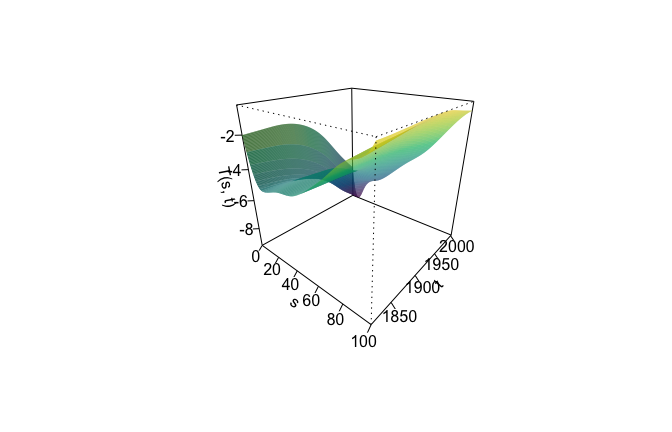

Figure 3. Estimated functional trend of log mortality rates in France, 1816-2002.

```r
plot(fit_fr, type = "surface", theta = 40)
```

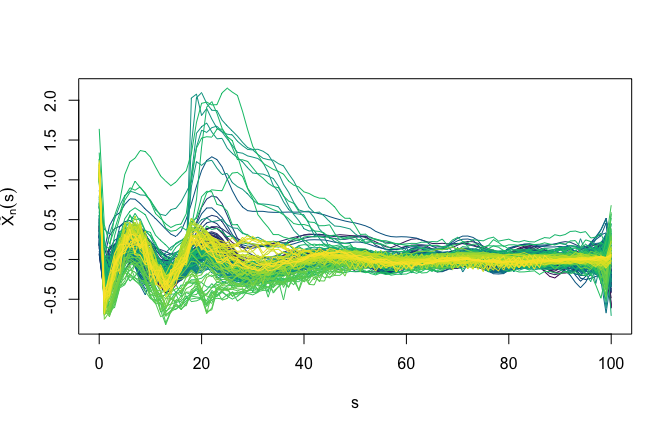

Figure 4. Detrended log mortality curves.

```r
plot(fit_fr, type = "residuals")
```

The mean of the detrended curves is a simple diagnostic, since $\tilde X_n$ should have mean close to zero for every age. The smoothing parameters of the supplementary code are much larger here, and the resulting trend misses the steep fall of mortality after birth:

```r
fit_fr_s <- ftrend(Ylog[, train], s = ages, t = years[train], select = "reml-supplement",
                   control = ftrend_control(supp_k = "te-default"))
rbind(cv = fit_fr$lambda, supplement = fit_fr_s$lambda)
```

```
#>                 lambda1     lambda2
#> cv         2.701616e-15 0.006723153
#> supplement 2.263118e-02 0.010573376
```

```r
rbind(cv = range(rowMeans(residuals(fit_fr))),
      supplement = range(rowMeans(residuals(fit_fr_s))))
```

```
#>                  [,1]      [,2]
#> cv         -0.3155963 0.6344765
#> supplement -0.7220575 3.0115181
```

The remaining bias at age 0 with the default selection comes from the basis: ten equally spaced cubic B-splines on ages 0–100 cannot follow the fall of mortality in the first years of life.

### Forecasting

Following Section 5 of the paper, the detrended series is projected onto $r = 4$ functional principal components, each score series is modelled by an ARMA model chosen by AIC, and the forecasts are added to the trend forecast of equation (5), $\hat T_{N+h}(s) = \hat T(s, 1) + (h/N)\,\partial_t \hat T(s, t)|_{t=1}$. For comparison, the same procedure is applied to the original series with ARIMA$(p, 1, q)$ models and no trend. The paper selected the models with an automatic ARIMA procedure, so the orders below, and hence the errors, may differ slightly from those reported there.

```r
fpca_forecast <- function(Z, h, r = 4, d = 0) {
  mu <- rowMeans(Z)
  pc <- prcomp(t(Z - mu), center = FALSE)
  phi <- pc$rotation[, seq_len(r)]
  scores <- pc$x[, seq_len(r)]
  orders <- expand.grid(p = 0:3, q = 0:2)
  fc <- sapply(seq_len(r), function(j) {
    fits <- lapply(seq_len(nrow(orders)), function(i) tryCatch(
      arima(scores[, j], order = c(orders$p[i], d, orders$q[i]),
            include.mean = (d == 0)), error = function(e) NULL))
    best <- fits[[which.min(sapply(fits, function(f) if (is.null(f)) Inf else AIC(f)))]]
    predict(best, n.ahead = h)$pred
  })
  mu + phi %*% t(matrix(fc, h))
}

h <- 4
test <- Ylog[, !train]
X_tilde <- residuals(fit_fr)
Yhat_trend <- forecast_trend(fit_fr, h = h, s = ages) + fpca_forecast(X_tilde, h)
Yhat_none <- fpca_forecast(Ylog[, train], h, d = 1)

# L1 distance on the rescaled domain [0, 1], summed over the four years
l1 <- function(A, B) sum(colSums(abs(A - B) * ftrend:::quad_weights(ages / 100)))
c(without_trend = l1(test, Yhat_none), with_trend = l1(test, Yhat_trend))
```

```
#> without_trend    with_trend
#>     0.4656889     0.3465266
```

Figure 5 compares the forecasts with the observed curves.

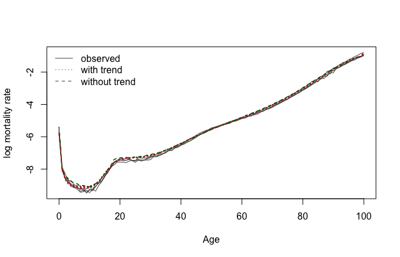

Figure 5. Observed log mortality curves 2003-2006 (solid) and forecasts with (dotted) and without (dashed) the functional trend.

```r
matplot(ages, test, type = "l", lty = 1, col = "grey30", xlab = "Age",
        ylab = "log mortality rate")
matlines(ages, Yhat_trend, lty = 3, col = "firebrick", lwd = 1.5)
matlines(ages, Yhat_none, lty = 2, col = "darkgreen")
legend("topleft", c("observed", "with trend", "without trend"),
       lty = c(1, 3, 2), col = c("grey30", "firebrick", "darkgreen"), bty = "n")
```

## References

Kokoszka, Piotr, and Gabriel Young. 2017. “Testing Trend Stationarity of Functional Time Series with Application to Yield and Daily Price Curves.” *Statistics and Its Interface* 10 (1): 81–92.

Martínez-Hernández, Israel, and Marc G. Genton. 2021. “Nonparametric Trend Estimation in Functional Time Series with Application to Annual Mortality Rates.” *Biometrics* 77 (3): 866–78.

Wood, Simon N. 2006. “Low-Rank Scale-Invariant Tensor Product Smooths for Generalized Additive Mixed Models.” *Biometrics* 62 (4): 1025–36.